# DATA 624: PREDICTIVE ANALYTICS HW2

# 3.4

What Box-Cox transformation would you select for your retail data (from Exercise 7 in Section [2.10](https://otexts.com/fpp3/graphics-exercises.html#graphics-exercises))?

I would rely on `features`=`guerrero` since its designed to be the best fit.

```r
# data provided
set.seed(123)
myseries <- aus_retail |>
  filter(`Series ID` == sample(aus_retail$`Series ID`,1))
head(myseries)
```

| State | Industry | Series ID | Month | Turnover |
| --- | --- | --- | --- | --- |
| Victoria | Household goods retailing | A3349643V | 1982 Apr | 173.1 |
| Victoria | Household goods retailing | A3349643V | 1982 May | 179.5 |
| Victoria | Household goods retailing | A3349643V | 1982 Jun | 167.3 |
| Victoria | Household goods retailing | A3349643V | 1982 Jul | 174.5 |
| Victoria | Household goods retailing | A3349643V | 1982 Aug | 178.1 |
| Victoria | Household goods retailing | A3349643V | 1982 Sep | 179.6 |

```r
(myseries_lambda <- myseries%>%
        features(Turnover,features = guerrero)%>%
          pull(lambda_guerrero))
```

```
[1] 0.2151641
```

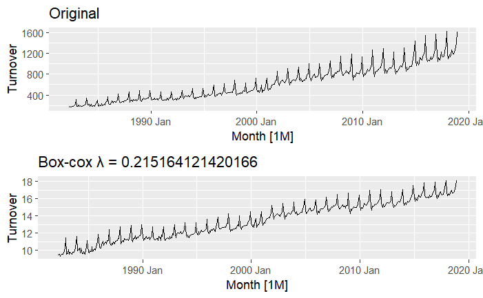

```r
fig1 <- myseries%>%
          autoplot(Turnover)

fig2 <- myseries%>%
        autoplot(box_cox(Turnover,myseries_lambda))
fig2<-fig2+ylab("Turnover")

plot_grid(fig1+labs(title = "Original"),
          fig2+labs(title = paste("Box-cox λ =",myseries_lambda)), nrow=2)
```

# 3.5

For the following series, find an appropriate Box-Cox transformation in order to stabilize the variance.

# i

Tobacco from `aus_production`

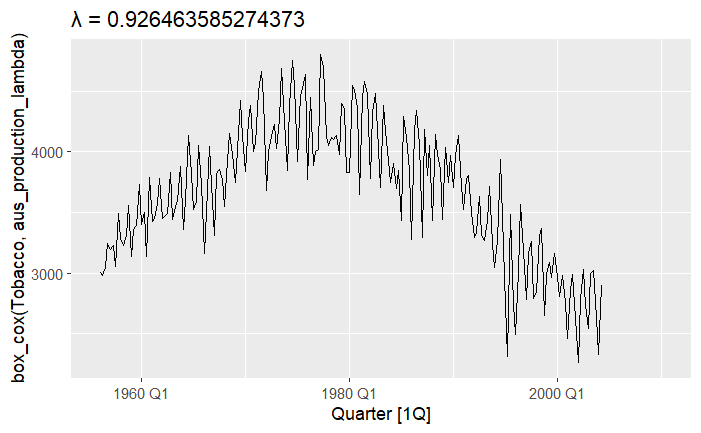

```r
aus_production_lambda<-aus_production%>%
  features(Tobacco,features=guerrero)%>%
  pull(lambda_guerrero)

aus_production%>%
  autoplot(box_cox(Tobacco,aus_production_lambda))+
  labs(title =paste("λ =",aus_production_lambda),ylab="" )
```

# ii

Economy class passengers between Melbourne and Sydney from `ansett`

```r
head(ansett)
```

| Week | Airports | Class | Passengers |
| --- | --- | --- | --- |
| 1989 W28 | ADL-PER | Business | 193 |
| 1989 W29 | ADL-PER | Business | 254 |
| 1989 W30 | ADL-PER | Business | 185 |
| 1989 W31 | ADL-PER | Business | 254 |
| 1989 W32 | ADL-PER | Business | 191 |
| 1989 W33 | ADL-PER | Business | 136 |

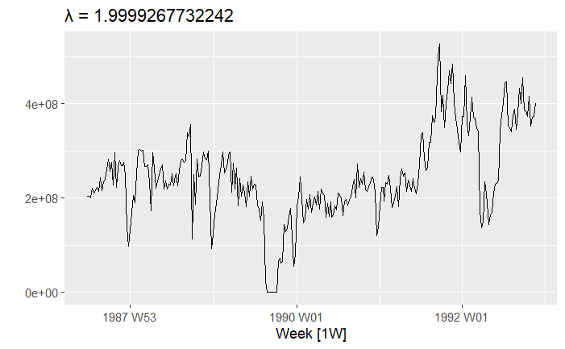

```r
ansett_lambda<-ansett%>%
  filter(Class=="Economy"& Airports=='MEL-SYD')%>%
  features(Passengers,features=guerrero)%>%
  pull(lambda_guerrero)

ansett%>%
  filter(Class=="Economy"& Airports=='MEL-SYD')%>%
  autoplot(box_cox(Passengers,ansett_lambda))+
  labs(title =paste("λ =",ansett_lambda), y=" " )
```

# iii

Pedestrian counts at Southern Cross Station from `pedestrian`.

```r
head(pedestrian)
```

| Sensor | Date_Time | Date | Time | Count |
| --- | --- | --- | --- | --- |
| Birrarung Marr | 2015-01-01 00:00:00 | 2015-01-01 | 0 | 1630 |
| Birrarung Marr | 2015-01-01 01:00:00 | 2015-01-01 | 1 | 826 |
| Birrarung Marr | 2015-01-01 02:00:00 | 2015-01-01 | 2 | 567 |
| Birrarung Marr | 2015-01-01 03:00:00 | 2015-01-01 | 3 | 264 |
| Birrarung Marr | 2015-01-01 04:00:00 | 2015-01-01 | 4 | 139 |
| Birrarung Marr | 2015-01-01 05:00:00 | 2015-01-01 | 5 | 77 |

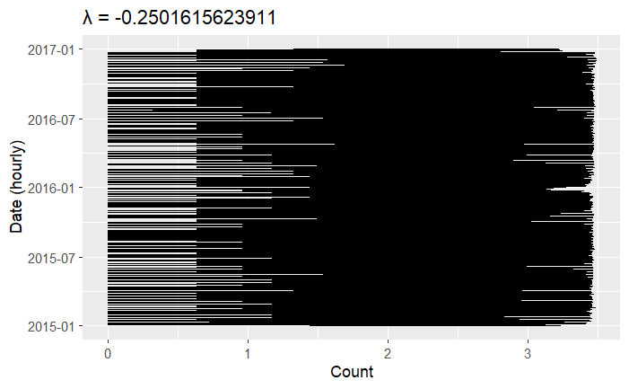

```r
pedestrian_lambda<-pedestrian%>%
  filter(Sensor=="Southern Cross Station")%>%
  features(Count,features=guerrero)%>%
  pull(lambda_guerrero)

pedestrian%>%
  filter(Sensor=="Southern Cross Station")%>%
  autoplot(box_cox(Count,pedestrian_lambda))+
  coord_flip()+
  labs(title =paste("λ =",pedestrian_lambda),x = "Date (hourly)",
       y="Count" )
```

# 3.7

Consider the last five years of the Gas data from `aus_production`.

```r
gas <- tail(aus_production, 5*4) |> select(Gas)

head(gas)
```

| Gas | Quarter |
| --- | --- |
| 221 | 2005 Q3 |
| 180 | 2005 Q4 |
| 171 | 2006 Q1 |
| 224 | 2006 Q2 |
| 233 | 2006 Q3 |
| 192 | 2006 Q4 |

# a.

Plot the time series. Can you identify seasonal fluctuations and/or a trend-cycle?

*Looks like the trend from 2006-2010 is upwards. Seasonality is the high every 3rd quarter and low every 1rst Quarter*

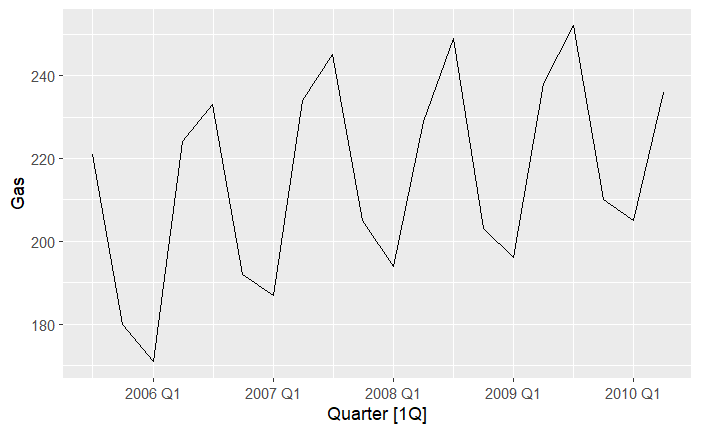

```r
gas%>%
  autoplot(Gas)
```

# b.

Use `classical_decomposition` with `type=multiplicative` to calculate the trend-cycle and seasonal indices.

Ref [3.4 video](https://youtu.be/1lj_hJBGg3A?si=Tupb9aKAtjbpff03&t=399)

```r
#example
# us_retail_employment |>
#   model(classical_decomposition(Employed, type = "additive")) |>
#   components()|>
#   autoplot()+xlab("Year")+
#   ggtitle("Classical additive decomposition of total US retail employment")
```

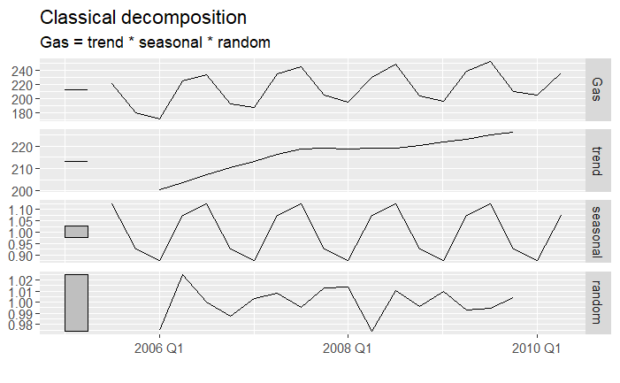

```r
gas%>%
  model(classical_decomposition(Gas,type= "multiplicative"))%>%
  components()%>%
  autoplot+xlab("")
```

# c.

Do the results support the graphical interpretation from part a?

*The results show a positive trend with quarterly seasonality so yes it does.*